# Healthcare Fraud Detection(DBSCAN & MeanShift & K-means)

## Exploratory Data Analysis

```r
#load libraries
library(dplyr)
```

```r
library(ggplot2)
library(plotly)
library(data.table)
library(zipcode)
suppressPackageStartupMessages(library(tidyverse))
library(stringr)
library(ggthemes)
suppressPackageStartupMessages(library(maps))
library(RColorBrewer)
library(cluster)
library(factoextra)
library(LPCM)
library(meanShiftR)
```

```r
setwd("~/Desktop/L/Anomaly Detection/session 4/HW4")
payment <- read.csv("inpatientCharges.csv")


data(zipcode)
nrow(zipcode)
```

```
## [1] 44336
```

```r
# get the basic info of the dataset
payment <-payment %>% arrange(Provider.Id, DRG.Definition)
head(payment)
```

```
##                                                    DRG.Definition
## 1                        039 - EXTRACRANIAL PROCEDURES W/O CC/MCC
## 2             057 - DEGENERATIVE NERVOUS SYSTEM DISORDERS W/O MCC
## 3      064 - INTRACRANIAL HEMORRHAGE OR CEREBRAL INFARCTION W MCC
## 4       065 - INTRACRANIAL HEMORRHAGE OR CEREBRAL INFARCTION W CC
## 5 066 - INTRACRANIAL HEMORRHAGE OR CEREBRAL INFARCTION W/O CC/MCC
## 6                                        069 - TRANSIENT ISCHEMIA
##   Provider.Id                    Provider.Name Provider.Street.Address
## 1       10001 SOUTHEAST ALABAMA MEDICAL CENTER  1108 ROSS CLARK CIRCLE
## 2       10001 SOUTHEAST ALABAMA MEDICAL CENTER  1108 ROSS CLARK CIRCLE
## 3       10001 SOUTHEAST ALABAMA MEDICAL CENTER  1108 ROSS CLARK CIRCLE
## 4       10001 SOUTHEAST ALABAMA MEDICAL CENTER  1108 ROSS CLARK CIRCLE
## 5       10001 SOUTHEAST ALABAMA MEDICAL CENTER  1108 ROSS CLARK CIRCLE
## 6       10001 SOUTHEAST ALABAMA MEDICAL CENTER  1108 ROSS CLARK CIRCLE
##   Provider.City Provider.State Provider.Zip.Code
```

[output cut: 20 more lines]

```r
str(payment)
```

```
## 'data.frame':    163065 obs. of  12 variables:
##  $ DRG.Definition                      : Factor w/ 100 levels "039 - EXTRACRANIAL PROCEDURES W/O CC/MCC",..: 1 2 3 4 5 6 7 8 10 11 ...
##  $ Provider.Id                         : int  10001 10001 10001 10001 10001 10001 10001 10001 10001 10001 ...
##  $ Provider.Name                       : Factor w/ 3201 levels "ABBEVILLE GENERAL HOSPITAL",..: 2519 2519 2519 2519 2519 2519 2519 2519 2519 2519 ...
##  $ Provider.Street.Address             : Factor w/ 3326 levels "#1 MEDICAL PARK DRIVE",..: 319 319 319 319 319 319 319 319 319 319 ...
##  $ Provider.City                       : Factor w/ 1977 levels "ABBEVILLE","ABERDEEN",..: 455 455 455 455 455 455 455 455 455 455 ...
##  $ Provider.State                      : Factor w/ 51 levels "AK","AL","AR",..: 2 2 2 2 2 2 2 2 2 2 ...
##  $ Provider.Zip.Code                   : int  36301 36301 36301 36301 36301 36301 36301 36301 36301 36301 ...
##  $ Hospital.Referral.Region.Description: Factor w/ 306 levels "AK - Anchorage",..: 3 3 3 3 3 3 3 3 3 3 ...
##  $ Total.Discharges                    : int  91 38 84 169 33 37 13 27 33 21 ...
##  $ Average.Covered.Charges             : Factor w/ 160236 levels "$10000.36","$10000.64",..: 97796 56746 109691 82858 43615 58349 48134 53526 70533 123448 ...
##  $ Average.Total.Payments              : Factor w/ 147842 levels "$10000.05","$10000.07",..: 93930 76582 2048 108306 70158 59739 76188 71714 98580 11963 ...
##  $ Average.Medicare.Payments           : Factor w/ 150328 levels "$10000.09","$10000.35",..: 86548 67974 143455 99990 61986 48657 73067 52367 98041 4229 ...
```

```r
# convert the average to numeric
p1 <- strsplit(x = as.character(payment$Average.Covered.Charges),split = "$",fixed = T)
payment$Average.Covered.Charges <- as.numeric(sapply(p1, '[[',2))
p1 <- strsplit(x = as.character(payment$Average.Medicare.Payments),split = "$",fixed = T)
payment$Average.Medicare.Payments <- as.numeric(sapply(p1, '[[',2))
p1 <- strsplit(x = as.character(payment$Average.Total.Payments),split = "$",fixed = T)
payment$Average.Total.Payments <- as.numeric(sapply(p1, '[[',2))

colnames(payment)
```

```
##  [1] "DRG.Definition"
##  [2] "Provider.Id"
##  [3] "Provider.Name"
##  [4] "Provider.Street.Address"
##  [5] "Provider.City"
##  [6] "Provider.State"
##  [7] "Provider.Zip.Code"
##  [8] "Hospital.Referral.Region.Description"
##  [9] "Total.Discharges"
## [10] "Average.Covered.Charges"
## [11] "Average.Total.Payments"
## [12] "Average.Medicare.Payments"
```

```r
anyNA(payment)
```

```
## [1] FALSE
```

## Feature Engineering (improvement of previous features)

- Lead
  - According the dataset and information from website, DRG’s full name is diagnosis-realted group, and is a patient classification system that standardizes prospective payment to hospital. (sources:https://hmsa.com/portal/provider/zav_pel.fh.DIA.650.htm)
  - Hospital referral regions (HRRs) represent regional health care market for tertiary medical care that generally requires the services of a major referral center. (sources: http://archive.dartmouthatlas.org/data/region/ )
  - To identify the frauds, we should at least narrow down our dataset and ensure that we the comparisons are conducted under the same DRG definition with the relatively same oevrall situation, where we can use state or city to group all the providers.
- Analysis
  - Use DRG definition and Hospital.Referral.Region.Description to divide the whole dataset
  - Get the mean and median values of each city’s total discharges, average covered charges, average total payments, and average medicare payments by each DRG definition within the same Hospital Referral Region.
  - Append the average and median statistics back to the data to derive the ratios and also add insurance covered ratio and discharge’s average covered charges to the new dataset
- R code: Attached below

```r
DRG_Referral_median <- payment %>%
  group_by(DRG.Definition, Hospital.Referral.Region.Description)%>%
  summarise(median_total_discharges = median(Total.Discharges),
            median_average_covered_charges = median(Average.Covered.Charges),
            median_average_total_payments = median(Average.Total.Payments),
            median_average_medicare_payments = median(Average.Medicare.Payments),
            median_avg_covered_discharge = median(Average.Covered.Charges/Total.Discharges),
            median_avg_cover_total = median(Average.Covered.Charges/Average.Total.Payments),
            median_avg_total_discharge = median(Average.Total.Payments/Total.Discharges),
            median_avg_medicare_discharge = median(Average.Medicare.Payments/Total.Discharges),
            median_count_trans = n())
head(DRG_Referral_median)
```

```
## # A tibble: 6 x 11
## # Groups:   DRG.Definition [1]
##   DRG.Definition Hospital.Referr… median_total_di… median_average_…
##   <fct>          <fct>                       <dbl>            <dbl>
## 1 039 - EXTRACR… AK - Anchorage                 23           34805.
## 2 039 - EXTRACR… AL - Birmingham                25           35841.
## 3 039 - EXTRACR… AL - Dothan                    68           36285.
## 4 039 - EXTRACR… AL - Huntsville                81           18879.
## 5 039 - EXTRACR… AL - Mobile                    24           15896.
## 6 039 - EXTRACR… AL - Montgomery                67           16921.
## # … with 7 more variables: median_average_total_payments <dbl>,
## #   median_average_medicare_payments <dbl>,
## #   median_avg_covered_discharge <dbl>, median_avg_cover_total <dbl>,
## #   median_avg_total_discharge <dbl>, median_avg_medicare_discharge <dbl>,
## #   median_count_trans <int>
```

```r
# get ratios based on the DRG_Referral_median dataframe
ratios <- payment %>%
       left_join(DRG_Referral_median, by=c("DRG.Definition","Hospital.Referral.Region.Description")) %>%
       mutate(
            ratio_total_discharges          = Total.Discharges/median_total_discharges,
            ratio_median_covered_charges   = Average.Covered.Charges/median_average_covered_charges,
            ratio_median_total_payments    = Average.Total.Payments/median_average_total_payments,
            ratio_median_medicare_payments = Average.Medicare.Payments/median_average_medicare_payments,
            ratio_diff_insurance_covered = Average.Medicare.Payments/Average.Total.Payments - median_average_medicare_payments / median_average_total_payments,
            ratio_median_covered_discharge = (Average.Covered.Charges/Total.Discharges)/ median_avg_covered_discharge,
            ratio_median_totalpay_discharge = (Average.Total.Payments/Total.Discharges)/ median_avg_total_discharge,
            ratio_median_medicare_discharge = (Average.Medicare.Payments/Total.Discharges)/ median_avg_medicare_discharge,
            ratio_diff_median_total_payments = (Average.Covered.Charges/Average.Total.Payments) -(median_avg_cover_total/ median_average_total_payments)) %>%
       select(-median_total_discharges,
              - median_average_covered_charges,
              - median_average_total_payments,
              - median_average_medicare_payments,
              - median_avg_covered_discharge,
              - median_avg_cover_total,
              -  median_avg_total_discharge,
              - median_avg_medicare_discharge,
              - median_count_trans,
              -Total.Discharges,
              -Average.Covered.Charges,
              -Average.Total.Payments,
              -Average.Medicare.Payments
           ) %>% arrange(Provider.Id, DRG.Definition)
#%>%
#           select(Provider.Id,DRG.Definition,Provider.Name,Provider.State,ratio_total_discharges,ratio_average_covered_charges,ratio_average_total_payments,ratio_average_medicare_payments)

head(ratios)
```

```
##                                                    DRG.Definition
## 1                        039 - EXTRACRANIAL PROCEDURES W/O CC/MCC
## 2             057 - DEGENERATIVE NERVOUS SYSTEM DISORDERS W/O MCC
## 3      064 - INTRACRANIAL HEMORRHAGE OR CEREBRAL INFARCTION W MCC
## 4       065 - INTRACRANIAL HEMORRHAGE OR CEREBRAL INFARCTION W CC
## 5 066 - INTRACRANIAL HEMORRHAGE OR CEREBRAL INFARCTION W/O CC/MCC
## 6                                        069 - TRANSIENT ISCHEMIA
##   Provider.Id                    Provider.Name Provider.Street.Address
## 1       10001 SOUTHEAST ALABAMA MEDICAL CENTER  1108 ROSS CLARK CIRCLE
## 2       10001 SOUTHEAST ALABAMA MEDICAL CENTER  1108 ROSS CLARK CIRCLE
## 3       10001 SOUTHEAST ALABAMA MEDICAL CENTER  1108 ROSS CLARK CIRCLE
## 4       10001 SOUTHEAST ALABAMA MEDICAL CENTER  1108 ROSS CLARK CIRCLE
## 5       10001 SOUTHEAST ALABAMA MEDICAL CENTER  1108 ROSS CLARK CIRCLE
## 6       10001 SOUTHEAST ALABAMA MEDICAL CENTER  1108 ROSS CLARK CIRCLE
##   Provider.City Provider.State Provider.Zip.Code
```

[output cut: 41 more lines]

- Conclusion
  - Rather than use DRG defination and State to group the providers, I use hospitla referral regions to divide the whole dataset. That is, to ensure the fraud detection is under the same DRG definition and the same hospital referral regions. The main reason to use hospital referral regions is even though I narrow down the dataset to each state, different cities have different infrastructure levels and economic conditions. Even in the same city, areas in suburban and urban might have differenet conditions. - Besides, my previous analysis is based on the average level compared to the overall level of cases. In this HW, I will use median value instead. Because if I use the mean value, it may be affecetd by the abnormal values while median value will be more objective.
  - Finally, I add three more features in my feature engineering process, including the ratio of each provider’s total payment per discharge to the median level under the benchmark of DRG definition and hospital referral regions, the ratio of each provider’s medicare payment per discharge to the median level under the benchmark of DRG definition and hospital referral regions, and the difference between the ratio of each provider’s average covered charges to average total payments and the median ratio under the benchmark of DRG definition and hospital referral regions.

## standardization

- Lead
  - It is important to standardize variables to ensure they receive the same weight in analysis
  - Approaches such as Z-score can help us to standardize
- Analysis
  - In this part, I will just use the function scale to standardize the data
- R code: Attached bellow

```r
# select variables
data<- ratios[,9:17]

#scale the data
data <- scale(data)
head(data)
```

```
##      ratio_total_discharges ratio_median_covered_charges
## [1,]              0.1190849                   -0.3885299
## [2,]              1.2003576                   -0.3028695
## [3,]              2.0928648                   -0.1440005
## [4,]              2.3204429                   -0.3154818
## [5,]              0.4442336                   -0.4841403
## [6,]              0.9933054                   -0.3070941
##      ratio_median_total_payments ratio_median_medicare_payments
## [1,]                 0.008218895                    0.001366755
## [2,]                -0.155245311                   -0.196012361
## [3,]                -0.201913242                   -0.242645664
## [4,]                -0.007466681                   -0.025910643
## [5,]                -0.024050367                    0.148863591
## [6,]                -0.024528228                    0.590653159
##      ratio_diff_insurance_covered ratio_median_covered_discharge
```

[output cut: 20 more lines]

```r
data2 <- data
rownames(data2) <- ratios$Provider.Name
```

- Conclusion
  - As shown above, I have standardized the data and it can be used for further analysis.

## Variable Selection (Before clustering)

- Lead
  - Before clustering, we need to examine the if it is necessary to conduct factor analysis.
  - Variables with high correlations will have a great impact on the clustering result and
  - The function pairs.panels in the psych package can examine the correlation between each variable
  - Bartlett’s Test of Sphericity is to see if there are at least some non-zero correlations by comparing correlation matrix to an identity matrix. A significant test indicates suitability for factor analysis.
  - KMO Measure of Sampling Adequacy compares partial correlation matrix to pairwise correlation matrix. A partial correlation is a correlation after partialing out all other correlations. If the variables are strongly related, partial correlations should be small and MSA close to 1. If MSA > 0.5, data is suitable for factor analysis.
- Analysis
  - Use function pairs.panels to get the plot of correlations between each variables
  - Find out if there are variables have correlations larger than 0.5
  - Use cortest.bartlett function and check the significance
  - Use KMO function and check out MSA for each variable
- R code: Attached below

```r
# examine the correlations of the variables
library(psych)
```

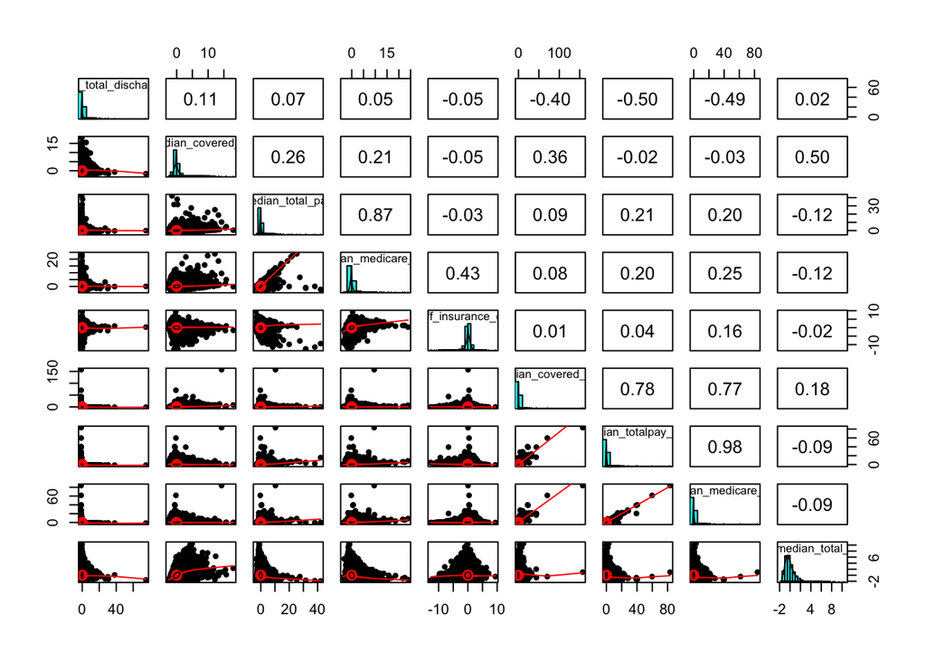

```r
pairs.panels(data)
```

```r
# Bartlett’s Test of Sphericity
library(psych)
cortest.bartlett(cor(data),n = 30)
```

```
## $chisq
## [1] 241.22
##
## $p.value
## [1] 3.292349e-32
##
## $df
## [1] 36
```

```r
# KMO Measure of Sampling Adequacy (MSA)

KMO(r = cor(data))
```

```
## Kaiser-Meyer-Olkin factor adequacy
## Call: KMO(r = cor(data))
## Overall MSA =  0.51
## MSA for each item =
##           ratio_total_discharges     ratio_median_covered_charges
##                             0.98                             0.48
##      ratio_median_total_payments   ratio_median_medicare_payments
##                             0.33                             0.36
##     ratio_diff_insurance_covered   ratio_median_covered_discharge
##                             0.13                             0.79
##  ratio_median_totalpay_discharge  ratio_median_medicare_discharge
##                             0.61                             0.62
## ratio_diff_median_total_payments
##                             0.64
```

- Conclusion
  - As we can see, some variables have high correlations with each other. For example, the correlation between ratio_average_total_payments and ratio_average_medicare_payments is 0.9, which is larger than 0.5. So, before conducting kmeans clustering, we need to solve the provblem of high correlations. As for the Bartlett’s Test of Sphericity, the p value is less than 0.05, which means it is significant. Meanwhile, the result of KMO Measure of Sampling Adequacy also shows we need to solve the problem of high correlations.

## Approaches to solve the problem (use PCA in this HW)

- Lead
  - To solve the problems listed above, there are several approaches, including variable elimination, factor analysis, variable index, and use a different distance measure.
  - The simplest approach for dealing with this situation, if the correlations are very high (e.g., .80 or higher), is to eliminate one of the two variables from the analysis. The variable to be retained in the analysis should be selected based on its practical usefulness or actionability potential.
  - Use mahalanobis distance to cluster will eliminate the effect of high correlations
- Analysis
  - First, I try to calculate mahalanobis distance and then use the hclust fucntion to cluster
  - However, this method doesn’t work in this assignment. Because calculation of the Mahalanobis distance measure, especially when there are more than a few variables can be a complicated, time consuming, iterative procedure.So, I choose the simpliest approach, just eliminate one of the variable, that is, ratio_average_medicare_payments.

sources: Cluster Analysis Gets Complicated: https://www.trchome.com/docs/5-cluster-analysis-gets-complicated/file

- R code: Attached below

```r
# calculate mahalanobis distance
library(ClusterR)
mean <- colMeans(data)
sx<-cov(data)
d = mahalanobis(data, mean,sx)

### failed to use the mahalanobis in the hclust function

# eliminate the variable ratio_average_medicare_payments.
data1 <- ratios[,c(9,10,11,13,15,17)]
data1 <-scale(data1)
data1 <- as.data.frame(data1)


# use PCA to solve the problem of high correaltions

data.pca <- prcomp(data2,center = TRUE, scale. = TRUE)
print(data.pca)
```

```
## Standard deviations (1, .., p=9):
## [1] 1.77874392 1.39643417 1.27514602 1.02577095 0.78837583 0.65279084
## [7] 0.36009328 0.14763893 0.09328205
##
## Rotation (n x k) = (9 x 9):
##                                          PC1         PC2         PC3
## ratio_total_discharges           -0.31448671 -0.30580956  0.09025399
## ratio_median_covered_charges      0.09273381 -0.25848508  0.64309426
## ratio_median_total_payments       0.21219800 -0.58747378 -0.05407895
## ratio_median_medicare_payments    0.23505324 -0.62514451 -0.13873824
## ratio_diff_insurance_covered      0.09966896 -0.20066165 -0.19452676
## ratio_median_covered_discharge    0.46999993  0.15512283  0.26864195
## ratio_median_totalpay_discharge   0.52806922  0.15141230 -0.07045904
## ratio_median_medicare_discharge   0.53143610  0.12570386 -0.09424869
## ratio_diff_median_total_payments -0.01026007  0.02606789  0.65746080
##                                          PC4         PC5        PC6
## ratio_total_discharges            0.09705909 -0.86162016 -0.2170496
## ratio_median_covered_charges      0.01129605 -0.01225475  0.5911502
## ratio_median_total_payments       0.35574605  0.20535303 -0.1592355
## ratio_median_medicare_payments   -0.08767124  0.12678722 -0.0820182
## ratio_diff_insurance_covered     -0.87846562 -0.11293114  0.1205060
## ratio_median_covered_discharge    0.02011102 -0.26755842  0.2077433
## ratio_median_totalpay_discharge   0.10083404 -0.18399305 -0.1807901
## ratio_median_medicare_discharge  -0.00628071 -0.20129386 -0.1713960
## ratio_diff_median_total_payments -0.27184036  0.20125118 -0.6720174
##                                           PC7          PC8          PC9
## ratio_total_discharges           -0.021512603 -0.005963513  0.003765539
## ratio_median_covered_charges     -0.401376581 -0.010754832  0.007782259
## ratio_median_total_payments       0.119984824 -0.570595276 -0.269936365
## ratio_median_medicare_payments    0.095982116  0.640111109  0.291981142
## ratio_diff_insurance_covered      0.004496445 -0.330803403 -0.059432787
## ratio_median_covered_discharge    0.752863413  0.017783632 -0.024487725
## ratio_median_totalpay_discharge  -0.325883784 -0.284300503  0.655377532
## ratio_median_medicare_discharge  -0.375314766  0.271929234 -0.638865765
## ratio_diff_median_total_payments  0.030662234  0.002852162  0.002355526
```

```r
summary(data.pca)
```

```
## Importance of components:
##                           PC1    PC2    PC3    PC4     PC5     PC6     PC7
## Standard deviation     1.7787 1.3964 1.2751 1.0258 0.78838 0.65279 0.36009
## Proportion of Variance 0.3515 0.2167 0.1807 0.1169 0.06906 0.04735 0.01441
## Cumulative Proportion  0.3515 0.5682 0.7489 0.8658 0.93486 0.98220 0.99661
##                            PC8     PC9
## Standard deviation     0.14764 0.09328
## Proportion of Variance 0.00242 0.00097
## Cumulative Proportion  0.99903 1.00000
```

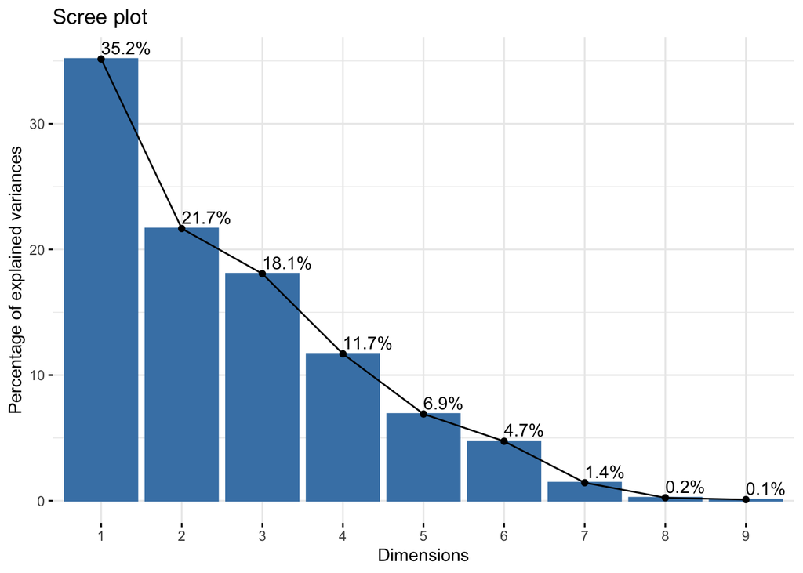

```r
# plot method
fviz_eig(data.pca, addlabels = TRUE)
```

```r
# choose the first five components
pca <- data.pca$x[,1:5]
head(pca)
```

```
##                                         PC1        PC2         PC3
## SOUTHEAST ALABAMA MEDICAL CENTER -0.9331083 -0.1540976  0.36612252
## SOUTHEAST ALABAMA MEDICAL CENTER -1.8096549 -0.4130150  0.02055345
## SOUTHEAST ALABAMA MEDICAL CENTER -2.3354051 -0.7359653  0.09671612
## SOUTHEAST ALABAMA MEDICAL CENTER -2.2783300 -1.0143830  0.10091842
## SOUTHEAST ALABAMA MEDICAL CENTER -1.0550315 -0.4366972 -0.39877746
## SOUTHEAST ALABAMA MEDICAL CENTER -1.2247485 -1.1432783 -0.08629757
##                                          PC4          PC5
## SOUTHEAST ALABAMA MEDICAL CENTER -0.32167817  0.477602391
## SOUTHEAST ALABAMA MEDICAL CENTER  0.03914185 -0.474227280
## SOUTHEAST ALABAMA MEDICAL CENTER  0.16900855 -1.202117742
## SOUTHEAST ALABAMA MEDICAL CENTER  0.08574209 -1.321782856
## SOUTHEAST ALABAMA MEDICAL CENTER -0.42897807 -0.007311394
## SOUTHEAST ALABAMA MEDICAL CENTER -1.36531216 -0.311245853
```

- Conclusion
  - I try to use mahalanobis distance to cluster but failed by the high volume of calculation. And I just eliminate the varaible ratio_median_medicare_payments, ratio_median_covered_discharge, and ratio_median_medicare_discharge since the correlation among these variables are very large. If we remain these variables to further cluster, it may cause some problems.
  - I offer two approaches here to solve the problem of high correlation, one is directly eliminate some variables with high correlations, the other is use PCA to reduce dimensions. In the previous homework, I use the first approach and in this homework, I will try to use the second, PCA.
  - As we can see, the first five components account for 93.49% the variability in the dataset. So, in the following analysis, I will use the first five componenets.

## DBSCAN

- Lead
  - DBSCAN is a density-based clustering non-parametric algorithm: given a set of points in some space, it groups together points that are closely packed together (points with many nearby neighbors), marking as outliers points that lie alone in low-density regions (whose nearest neighbors are too far away)
  - It is in the DBSCAN library and can be used to identify outlier. Basically, this method calculate the distance between points and look for points which are far away from others.
  - Two parameters need to be set, eps and MinPoints. Specifically, eps specifies a distance threshold under which two points are considered to be close; while MinPoints is the minimum number of points that have to be within a point’s eps before the point can start agglomerating.

(sources: https://www.datadoghq.com/blog/outlier-detection-algorithms-at-datadog/) (sources: https://en.wikipedia.org/wiki/DBSCAN)

- Analysis
  - Ramdomly choose 10000 rows in the PCA dataset as the sample dataset
  - Use kNNdistplot to find the optimal eps value
  - Use dbscan function to cluster the sample dataset
  - Combine the cluster result with the original dataset sample and calculate the average statistics to determine the outlier
- R code: Attached below

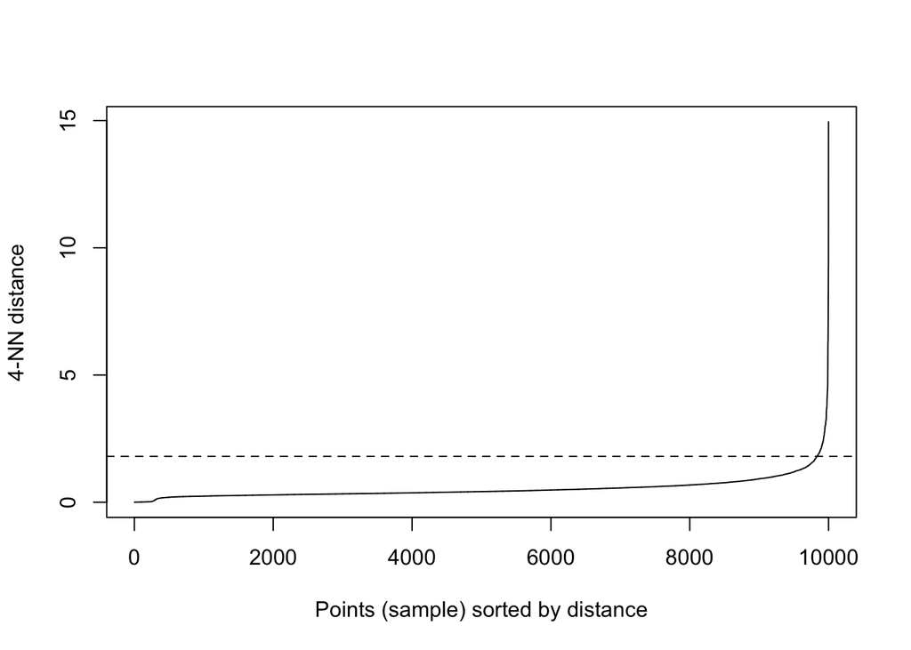

```r
# randomly select 10000 rows of the pca dataframe
set.seed(1)
sample <- pca[sample(nrow(pca),10000),]
aaa <- rownames(sample)
aa <-data.frame(Provider.Name = rownames(sample))
# find the suitable eps
library(dbscan)
kNNdistplot(sample, k = 4)
abline(h = 1.8, lty = 2)
```

```r
# compute DBSCAN
set.seed(123)
db<- fpc::dbscan(sample,eps = 1.8, MinPts = 5)
table(db$cluster)
```

```
##
##    0    1    2
##  103 9891    6
```

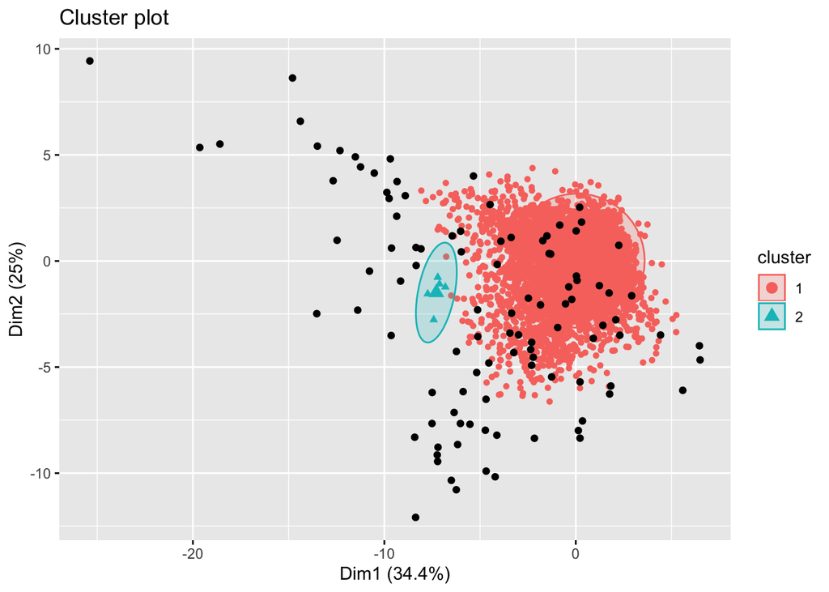

```r
#remove the rownames of sample
sample0 <- sample
rownames(sample0)<- NULL
# plot the DBSCAN clusters
fviz_cluster(db,sample0,stand = FALSE, geom = "point", ellipse.type = "norm")
```

```r
previous <- as.data.frame(sample)
previous$cluster <- db$cluster

mean_previous<- previous %>%
  group_by(cluster)%>%
  summarize(count = n(),
            mean_pc1 = mean(PC1),
            mean_pc2 = mean(PC2),
            mean_pc3 = mean(PC3),
            mean_pc4 = mean(PC4),
            mean_pc5 = mean(PC5))
mean_previous
```

```
## # A tibble: 3 x 7
##   cluster count mean_pc1 mean_pc2 mean_pc3 mean_pc4 mean_pc5
##     <dbl> <int>    <dbl>    <dbl>    <dbl>    <dbl>    <dbl>
## 1       0   103   4.90    -2.58     2.06    1.22     -1.05
## 2       1  9891  -0.0737   0.0197  -0.0206 -0.00964   0.0229
## 3       2     6   7.08    -2.00    -2.66   -0.171    -0.669
```

```r
# combine the cluster with the provider name
result <-table(aaa, db$cluster)
frame <- as.data.frame(result)

# filter the outliers
a1<-frame[frame$Var2==0,]
a1<- a1[a1$Freq>0,]
head(a1)
```

```
##                                          aaa Var2 Freq
## 16  ADVOCATE ILLINOIS MASONIC MEDICAL CENTER    0    1
## 163                  BAYONNE HOSPITAL CENTER    0    3
## 182           BERGEN REGIONAL MEDICAL CENTER    0    1
## 242                 BROOKWOOD MEDICAL CENTER    0    5
## 269        CAMPBELL COUNTY MEMORIAL HOSPITAL    0    1
## 317              CEDARS-SINAI MEDICAL CENTER    0    1
```

## Meanshift

- Lead
  - Mean shift is a hill climbing algorithm which involves shifting this kernel iteratively to a higher density region until convergence. Every shift is defined by a mean shift vector. The mean shift vector always points toward the direction of the maximum increase in the density. At every iteration the kernel is shifted to the centroid or the mean of the points within it.
  - Use mean shift we can cluster the dataset to find out outliers, and we can use meanShiftR to conduct the analysis
  - Compare to the LPCM package, meanShiftR has a quick speed.
- Analysis
  - Still use the previous sample data to conduct meanshift analysis
  - The parameter epsilonCluster is a scalar used to determine the minimum distance between distinct clusters. This distance is applied after all iterations have finished and in order of the rows of queryData. Here, I will try a small number with a large number and then try to get the appropriate number
  - Get the table of clusters, combine it with the previous dataset sample and calculate each components’ average statistics.
  - Combined cluster with provider name and to see the problematic providers.
- R code: Attached below

```r
#use meanShift function to cluster
cluster1 <- meanShift(sample,trainData = sample, nNeighbors = NROW(sample), algorithm = "LINEAR", kernelType = "NORMAL", bandwidth = rep(1, NCOL(sample)), alpha = 0, iterations = 10, epsilon = 1e-05, epsilonCluster = 0.5, parameters = NULL)

cluster2 <- meanShift(sample,trainData = sample, nNeighbors = NROW(sample), algorithm = "LINEAR", kernelType = "NORMAL", bandwidth = rep(1, NCOL(sample)), alpha = 0, iterations = 10, epsilon = 1e-05, epsilonCluster = 50, parameters = NULL)

table(cluster1$assignment)
```

```
##
##    1    2    3    4    5    6    7    8    9   10   11   12   13   14   15
## 9877   18   12    6    5    8    3   14    4    3    7    2    5   17    6
##   16   17   18   19   20   21   22   23
##    1    3    2    2    2    1    1    1
```

```r
table(cluster2$assignment)
```

```
##
##    1    2
## 9888  112
```

```r
# combine the cluster with the provider name
result2 <-table(aaa, cluster2$assignment)
frame2 <- as.data.frame(result2)

original <- as.data.frame(sample)
original$cluster <- cluster2$assignment

mean_original<- original %>%
  group_by(cluster)%>%
  summarize(count = n(),
            mean_pc1 = mean(PC1),
            mean_pc2 = mean(PC2),
            mean_pc3 = mean(PC3),
            mean_pc4 = mean(PC4),
            mean_pc5 = mean(PC5))

mean_original
```

```
## # A tibble: 2 x 7
##   cluster count mean_pc1 mean_pc2 mean_pc3 mean_pc4 mean_pc5
##     <dbl> <int>    <dbl>    <dbl>    <dbl>    <dbl>    <dbl>
## 1       1  9888  -0.0819   0.0146  -0.0129 -0.00852   0.0320
## 2       2   112   5.61    -2.03     1.07    1.01     -1.81
```

```r
# find out the each provider in outliers
a2<-frame2[frame2$Var2==2,]
a2<- a2[a2$Freq>0,]
head(a2)
```

```
##                                           aaa Var2 Freq
## 2605                       ADVENTIST GLENOAKS    2    1
## 2612 ADVOCATE ILLINOIS MASONIC MEDICAL CENTER    2    1
## 2661          ARIZONA REGIONAL MEDICAL CENTER    2    1
## 2759                  BAYONNE HOSPITAL CENTER    2    1
## 2774                BELLFLOWER MEDICAL CENTER    2    1
## 2778           BERGEN REGIONAL MEDICAL CENTER    2    1
```

## kmeans clustering

```r
#choose the best k
set.seed(1234)
within_ss = sapply(4:10,FUN = function(x) kmeans(x = sample,centers = x)$tot.withinss)
```

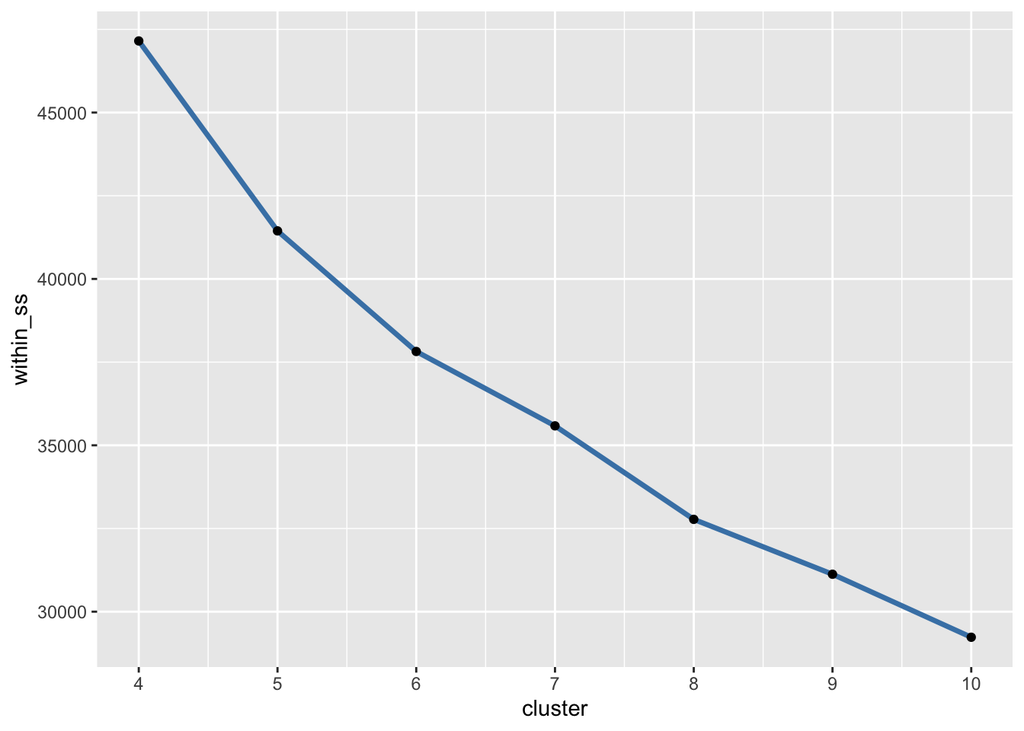

```r
ggplot(data=data.frame(cluster = 4:10,within_ss),aes(x=cluster,y=within_ss))+
  geom_line(col='steelblue',size=1.2)+
  geom_point()+
  scale_x_continuous(breaks=seq(4,10,1))
```

```r
set.seed(1234)
ratio_ss = sapply(4:10,FUN = function(x) {km = kmeans(x = sample,centers = x)
km$betweenss/km$totss} )
```

```
## Warning: did not converge in 10 iterations
```

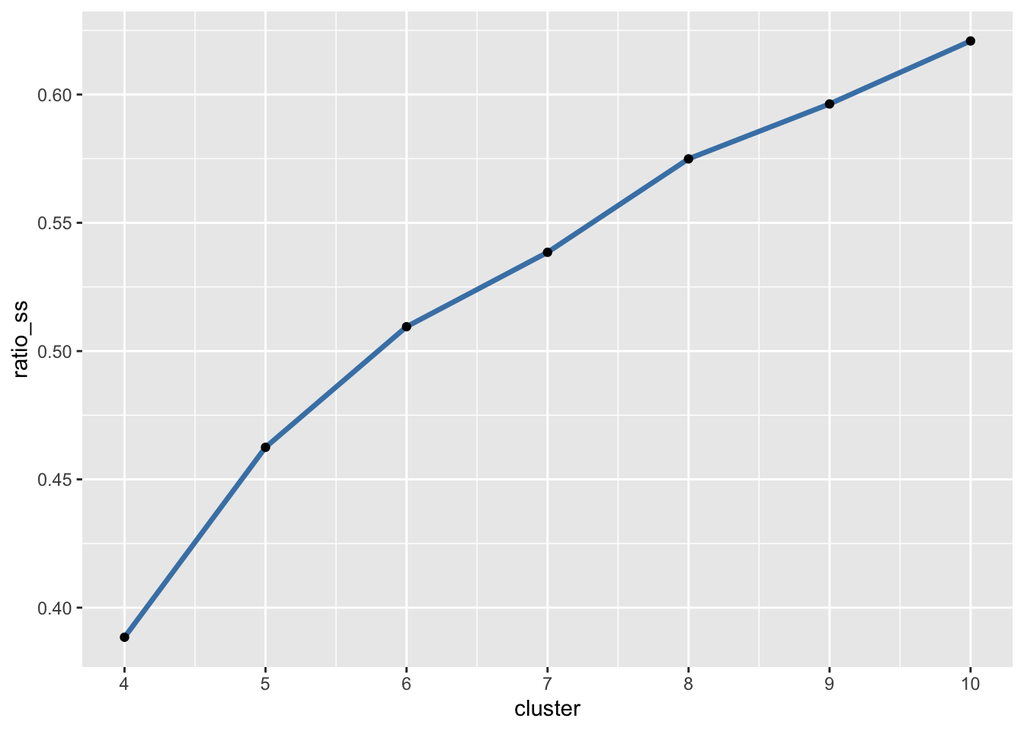

```r
ggplot(data=data.frame(cluster = 4:10,ratio_ss),aes(x=cluster,y=ratio_ss))+
  geom_line(col='steelblue',size=1.2)+
  geom_point()+
  scale_x_continuous(breaks=seq(4,10,1))
```

- Conclusion
  - Based on the warnings and two plots, the optimal number of cluster might be 5 or 8 and I will use these two to further analyze.

```r
# use the number of 5
set.seed(1234)
km = kmeans(sample,centers  = 5)
km$size;km$centers
```

```
## [1] 1339  804  629 5473 1755
```

```
##           PC1        PC2         PC3         PC4        PC5
## 1 -1.84068732 -0.8118561  0.15668453  0.27987783 -0.9176657
## 2  1.54015385 -3.0700827 -0.65332603  0.09909037  0.4843328
## 3  3.78020377  0.9903718 -0.04035579  0.17396837 -0.6456210
## 4 -0.24759618  0.4848374 -0.50457077  0.02782255  0.1425308
## 5  0.01269874  0.1116682  1.76313975 -0.39137992  0.3302734
```

```r
# use the number of 8
set.seed(1234)
km1 = kmeans(sample,centers  = 8)
km1$size;km1$centers
```

```
## [1]  726  821  169 3824 1204 2136  409  711
```

```
##          PC1        PC2        PC3         PC4         PC5
## 1 -0.2800761  0.7187916  0.5367923  2.14633246  0.42157478
## 2 -2.0497559 -1.2343807  0.2225576  0.29399875 -1.36587227
## 3  6.4837506  1.4236800  0.3503570  0.26871377 -1.55927186
## 4 -0.5635075  0.3633302 -0.6987259 -0.06988190  0.07675271
## 5  1.6853962  0.7176721 -0.5625076 -0.15663038 -0.08275922
## 6 -0.3571934  0.1735880  0.8677471 -0.53408427  0.24806306
## 7  0.8463713 -0.4428724  3.4618426 -0.59057459  0.28525888
## 8  1.6194230 -3.1998653 -0.7875086  0.03149035  0.49605558
```

## Compare the outlier size of three approaches

- Lead
  - DBSCAN, Meanshift and K-means are three clustering approaches. We can compare the result of these three methods and examine if the results are consistent.
- Analysis
  - Compare the size of the outliers we have identified correspongding to three methods.
- R code: Attached below

```r
comparison <- data.frame("DBSCAN" = c(109, 0.0109), "MeanShift" = c(112, 0.0112),"K-means" = c(169, 0.0169))
comparison
```

```
##     DBSCAN MeanShift  K.means
## 1 109.0000  112.0000 169.0000
## 2   0.0109    0.0112   0.0169
```

- Conclusion
  - In my sample dataset, DBSCAN and Meanshift identified the similar size of outliers while the outlier of K-means’s size is a little larger than these two. Overall, the results of these three approaches are consistent.